# Subjectivity in Data Analysis

Craig A. Sloss

2023-05-06

# Introduction and Setup

This notebook is a supplement to the article “Debunking the Police Part 1: Subjectivity in Mathematics” in *Questioning the Numbers*, showing the code used to generate the graphics and statistical results appearing in the article. (See https://questioning-the-numbers.ghost.io/) Section titles in this document correspond to the sections in the article. This notebook also contains some additional discussion of technical details that are not in the article.

The following packages are used in this notebook:

```r
require(tidyverse)
require(curl)
```

Download the full Uniform Crime Reporting Survey data from https://www150.statcan.gc.ca/t1/tbl1/en/tv.action?pid=3510017701:

```r
curl_download("https://www150.statcan.gc.ca/n1/tbl/csv/35100177-eng.zip", "ucr_full.zip")
unzip("ucr_full.zip")
ucr_full = read_csv("./35100177.csv")
```

Preview the data:

```r
ucr_full %>% head()
```

```
## # A tibble: 6 × 16
##   REF_DATE GEO    DGUID         Violations Statistics UOM   UOM_ID SCALAR_FACTOR
##      <dbl> <chr>  <chr>         <chr>      <chr>      <chr>  <dbl> <chr>
## 1     1998 Canada 2016A0000111… Total, al… Actual in… Numb…    223 units
## 2     1998 Canada 2016A0000111… Total, al… Rate per … Rate     257 units
## 3     1998 Canada 2016A0000111… Total, al… Percentag… Perc…    239 units
## 4     1998 Canada 2016A0000111… Total, al… Percentag… Perc…    239 units
## 5     1998 Canada 2016A0000111… Total, al… Unfounded… Numb…    223 units
## 6     1998 Canada 2016A0000111… Total, al… Percent u… Perc…    239 units
## # ℹ 8 more variables: SCALAR_ID <dbl>, VECTOR <chr>, COORDINATE <chr>,
## #   VALUE <dbl>, STATUS <chr>, SYMBOL <lgl>, TERMINATED <lgl>, DECIMALS <dbl>
```

Keep data only for Kitchener-Waterloo-Cambridge, and drop columns that are not needed for this analysis. To ensure that the results appearing in the newsletter can be replicated, limit the data to 2021 and earlier so that this gives the same results when additional years of data are added in the future:

```r
reported_crime_data = ucr_full %>%
  filter(GEO == "Kitchener-Cambridge-Waterloo, Ontario [35541]" &
           REF_DATE <= 2021) %>%
  select(REF_DATE, Violations, Statistics, VALUE)
reported_crime_data %>% head()
```

```
## # A tibble: 6 × 4
##   REF_DATE Violations                Statistics                            VALUE
##      <dbl> <chr>                     <chr>                                 <dbl>
## 1     1998 Total, all violations [0] Actual incidents                     31507
## 2     1998 Total, all violations [0] Rate per 100,000 population           7306.
## 3     1998 Total, all violations [0] Percentage change in rate               NA
## 4     1998 Total, all violations [0] Percentage contribution to the Crim…   100
## 5     1998 Total, all violations [0] Unfounded incidents                     NA
## 6     1998 Total, all violations [0] Percent unfounded                       NA
```

# Reported Crime Rates

This code produces a graph of the rate of violations per 100,000 population over time. The blue curve on the graph is fit using a GLM with a log-link function, for consistency with later analysis that calculates multiplicative trends. (The visual is not materially different from fitting a linear trend.) This graph uses all available data points.

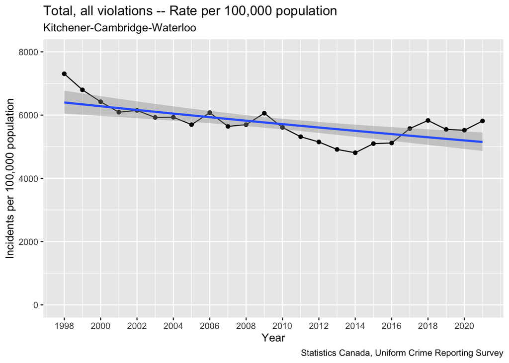

```r
overall_incidents_data = reported_crime_data %>%
  filter(Violations == "Total, all violations [0]" & Statistics == "Rate per 100,000 population")
ggplot(data = overall_incidents_data, aes(x = REF_DATE, y = VALUE)) +
  geom_line() +
  geom_point() +
  coord_cartesian(ylim = c(0, 8000)) +
  geom_smooth(method = "glm", method.args = list(family = Gamma(link = "log"))) +
  scale_x_continuous(breaks = seq(1998, 2021, 2)) +
  labs(title = "Total, all violations -- Rate per 100,000 population",
       subtitle = "Kitchener-Cambridge-Waterloo",
       x = "Year",
       y = "Incidents per 100,000 population",
       caption = "Statistics Canada, Uniform Crime Reporting Survey")
```

```r
ggsave("./total_reported_crime_rate_1998-2021.jpg", device = "jpeg")
```

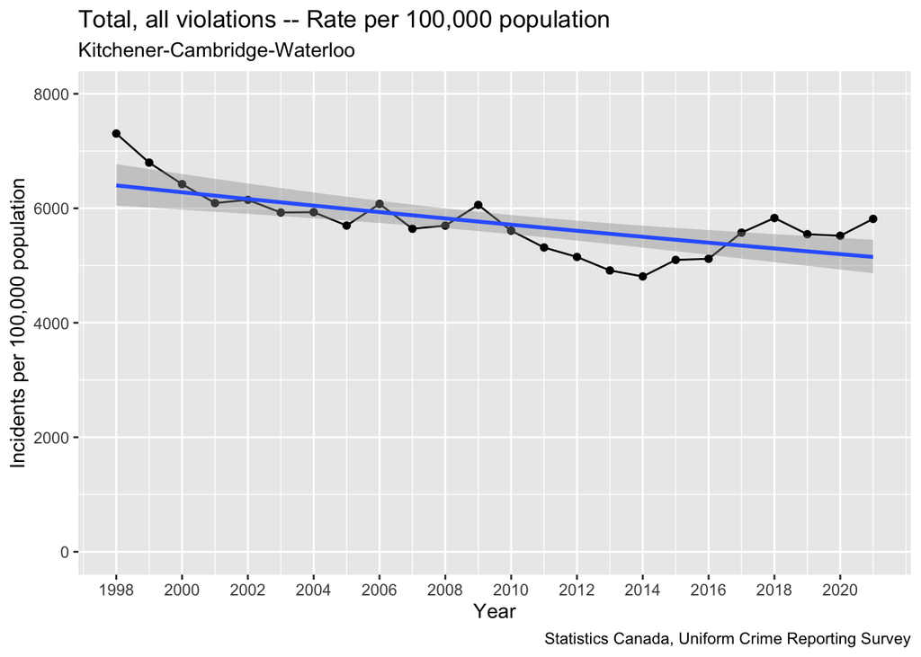

```r
overall_incidents_data = reported_crime_data %>%
  filter(Violations == "Total, all violations [0]" & Statistics == "Rate per 100,000 population")
ggplot(data = overall_incidents_data, aes(x = REF_DATE, y = VALUE)) +
  geom_line() +
  geom_point() +
  coord_cartesian(ylim = c(0, 8000)) +
  geom_smooth(method = "glm", method.args = list(family = Gamma(link = "log"))) +
  scale_x_continuous(breaks = seq(1998, 2021, 2)) +
  labs(title = "Total, all violations -- Rate per 100,000 population",
       subtitle = "Kitchener-Cambridge-Waterloo",
       x = "Year",
       y = "Incidents per 100,000 population",
       caption = "Statistics Canada, Uniform Crime Reporting Survey")
```

```r
ggsave("./total_reported_crime_rate_1998-2021_feature.jpg", device = "jpeg", width = 2400, height = 1200, units = "px")
ggsave("./total_reported_crime_rate_1998-2021_twitter.jpg", device = "jpeg", width = 2400, height = 1254, units = "px")
```

# How many data points to use?

This section produces two additional graphs to show how the direction of the trend changes if fewer points are used. This graph uses only the 8 most recent years:

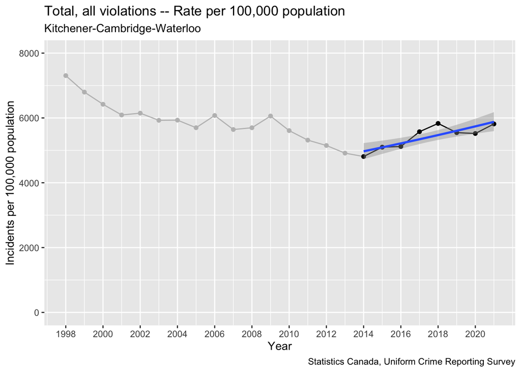

```r
ggplot(data = overall_incidents_data, aes(x = REF_DATE, y = VALUE)) +
  geom_line(colour = "grey") +
  geom_point(colour = "grey") +
  coord_cartesian(ylim = c(0, 8000)) +
  geom_point(data = overall_incidents_data %>% filter(REF_DATE >= 2014), colour = "black") +
  geom_line(data = overall_incidents_data %>% filter(REF_DATE >= 2014), colour = "black") +
  geom_smooth(data = overall_incidents_data %>% filter(REF_DATE >= 2014), method = "glm", method.args = list(family = Gamma(link = "log"))) +
  scale_x_continuous(breaks = seq(1998, 2021, 2)) +
  labs(title = "Total, all violations -- Rate per 100,000 population",
       subtitle = "Kitchener-Cambridge-Waterloo",
       x = "Year",
       y = "Incidents per 100,000 population",
       caption = "Statistics Canada, Uniform Crime Reporting Survey")
```

```r
ggsave("./total_reported_crime_rate_2014-2021.jpg", device = "jpeg")
```

This graph uses only the four most recent years:

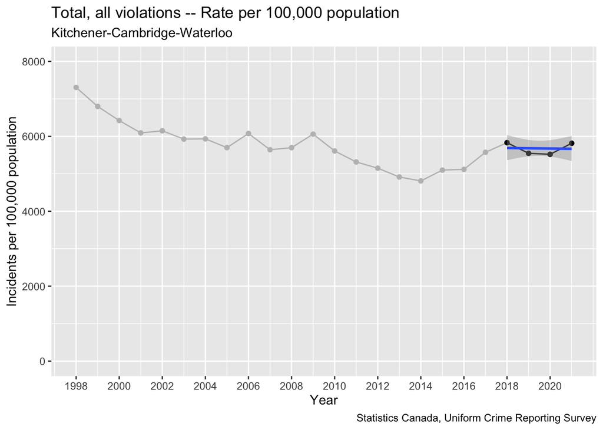

```r
ggplot(data = overall_incidents_data, aes(x = REF_DATE, y = VALUE)) +
  geom_line(colour = "grey") +
  geom_point(colour = "grey") +
  coord_cartesian(ylim = c(0, 8000)) +
  geom_point(data = overall_incidents_data %>% filter(REF_DATE >= 2018), colour = "black") +
  geom_line(data = overall_incidents_data %>% filter(REF_DATE >= 2018), colour = "black") +
  geom_smooth(data = overall_incidents_data %>% filter(REF_DATE >= 2018), method = "glm", method.args = list(family = Gamma(link = "log"))) +
  scale_x_continuous(breaks = seq(1998, 2021, 2)) +
  labs(title = "Total, all violations -- Rate per 100,000 population",
       subtitle = "Kitchener-Cambridge-Waterloo",
       x = "Year",
       y = "Incidents per 100,000 population",
       caption = "Statistics Canada, Uniform Crime Reporting Survey")
```

```r
ggsave("./total_reported_crime_rate_2018-2021.jpg", device = "jpeg")
```

# Trying different methods

This function calculates a series of multiplicative trend values, each using a different cutoff point for the data. The inputs to this function are:

- x is an array representing the time variable in the data
- y is an array containing the quantity for which we want to calculate a trend factor
- method is a string representing the form of the model used to determine the trend. There are three options to calculate a multiplicative trend: “log-gamma”, “log-normal”, and “log-inverse-gaussian”, each of which corresponds to a different error distribution assumption. The option “linear” will determine an additive trend using ordinary linear regression.

The output is a data frame with four columns:

- x_range indicates the starting point of the range of data used to calculate the trend factor. All data points corrsponding to x_range and later are included in the calculation. The last two years in the range are omitted from x_range because they correspond to too few points to perform a calculation.
- middle indicates the best estimate of the trend using the given number of data points. It is either expressed as a multiplicative trend, scaled so that it can be interpreted as plus or minus a number of percentage points (i.e. 1 is subtracted and the result multiplied by 100), or as a linear trend, depending on the option used for “method.”
- upper_ci and lower_ci indicate the upper and lower bounds of an approximate 95% confidence interval for middle. For multiplicative trends, the intervals are calculated on a log scale then exponentiated.

```r
trend_sensitivity_test = function(x, y, method = "log-gamma") {
  x_min = min(x)
  x_max = max(x) - 2
  x_range = x_min:x_max
  x_length = length(x_range)
  upper_ci = rep(NA, x_length)
  middle = rep(NA, x_length)
  lower_ci = rep(NA, x_length)
  data = data.frame(x, y)
  for (i in 1:x_length) {
    truncated_data = data %>%
      filter(x >= x_range[i])

    if (method == "log-gamma") {
      trend_glm = glm(y ~ x, data = truncated_data, family = Gamma(link = "log"))
    }
    else if (method == "linear") {
      trend_glm = glm(y ~ x, data = truncated_data, family = gaussian(link = "identity"))
    }
    else if (method == "log-normal") {
      trend_glm = glm(y ~ x, data = truncated_data, family = gaussian(link = "log"))
    }
    else if (method == "log-inverse-gaussian") {
      trend_glm = glm(y ~ x, data = truncated_data, family = inverse.gaussian(link = "log"))
    }
    else{
      print("Error: valid methods are log-gamma, linear, log-normal, or log-inverse-gaussian")
      stop()
    }

    se = summary(trend_glm)$coefficients[2,2]
    beta = trend_glm$coefficients[2]
    if (method == "linear") {
      upper_ci[i] = beta + 2 * se
      middle[i] = beta
      lower_ci[i] = beta - 2 * se
    }
    else {
      upper_ci[i] = (exp(beta + 2 * se) - 1) * 100
      middle[i] = (exp(beta) - 1) * 100
      lower_ci[i] = (exp(beta - 2 * se) - 1) * 100
    }
  }
  trend_result_data = data.frame(x_range, upper_ci, middle, lower_ci)
  return(trend_result_data)
}
```

Perform the trend sensitivity test on rates of all incidents over time:

```r
trend_result_data = trend_sensitivity_test(x = overall_incidents_data %>% pull(REF_DATE),
                                           y = overall_incidents_data %>% pull(VALUE),
                                           method = "log-gamma") %>%
  rename(years = x_range)
```

Numerical results:

```r
trend_result_data
```

```
##    years    upper_ci      middle    lower_ci
## 1   1998 -0.51202752 -0.93948456 -1.36510499
## 2   1999 -0.36099095 -0.77834845 -1.19395777
## 3   2000 -0.22659721 -0.65512609 -1.08181443
## 4   2001 -0.10892237 -0.56640103 -1.02178455
## 5   2002 -0.01994597 -0.52293326 -1.02339008
## 6   2003  0.11008539 -0.43876239 -0.98460115
## 7   2004  0.22434249 -0.38626666 -0.99315571
## 8   2005  0.37748185 -0.30230739 -0.97749287
## 9   2006  0.49666699 -0.27431121 -1.03937471
## 10  2007  0.78832255 -0.04018489 -0.86188177
## 11  2008  1.01488950  0.06451519 -0.87691775
## 12  2009  1.34704851  0.26118273 -0.81304874
## 13  2010  1.85786861  0.87706534 -0.09429364
## 14  2011  2.33990879  1.41863329  0.50565122
## 15  2012  2.81498779  1.89479237  0.98283270
## 16  2013  3.31180423  2.33961681  1.37657788
## 17  2014  3.67886857  2.42639266  1.18904709
## 18  2015  3.44330079  1.94769752  0.47371797
## 19  2016  3.61603907  1.59399861 -0.38858224
## 20  2017  2.25742284  0.29980478 -1.62033660
## 21  2018  3.14739094 -0.12649013 -3.29645876
## 22  2019  5.79120567  2.38710519 -0.90745973
```

Plot the results:

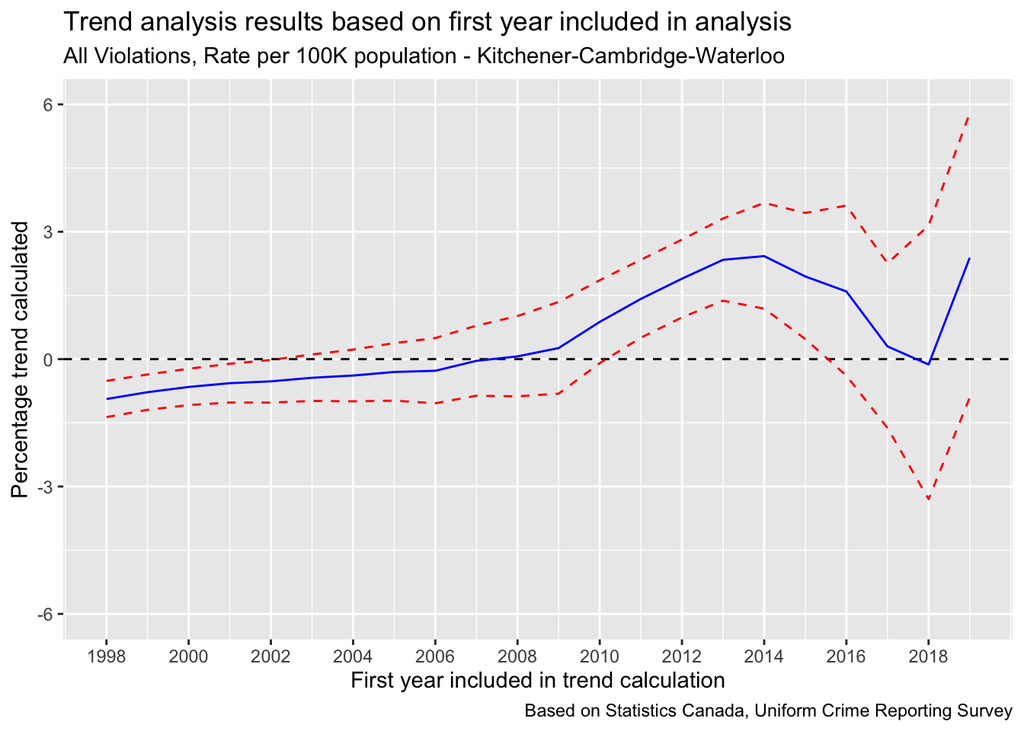

```r
ggplot(trend_result_data, aes(x = years, y = middle)) +
  geom_hline(yintercept = 0, colour = "black", linetype = "dashed") +
  geom_line(colour = "blue") +
  geom_line(aes(y = upper_ci), colour = "red", linetype = "dashed") +
  geom_line(aes(y = lower_ci), colour = "red", linetype = "dashed") +
  coord_cartesian(ylim = c(-6, 6)) +
  scale_x_continuous(breaks = seq(1998, 2019, 2)) +
  labs(title = "Trend analysis results based on first year included in analysis",
       subtitle = "All Violations, Rate per 100K population - Kitchener-Cambridge-Waterloo",
       x = "First year included in trend calculation",
       y = "Percentage trend calculated",
       caption = "Based on Statistics Canada, Uniform Crime Reporting Survey")
```

```r
ggsave("./total_reported_crime_rate_trend_sensitivity_analysis.jpg", device = "jpeg")
```

## Sensitivity testing – trend model distributional assumption

This section contains additional methodological sensitivity tests, beyond what was discussed in the article, to confirm that the decision to use a Gamma distribution with a log-link function to produce a multiplicative trend does not have a material impact on the results. Similar results are obtained assuming log-normal, log-inverse-Gaussian, and linear models. (The only difference is that the linear model produces an additive trend, rather than a multiplicative one, that is on a different scale than the log-link models.)

Using a log-normal distribution:

```r
trend_result_data_lognormal = trend_sensitivity_test(x = overall_incidents_data %>% pull(REF_DATE),
                                                     y = overall_incidents_data %>% pull(VALUE),
                                                     method = "log-normal") %>%
  rename(years = x_range)
```

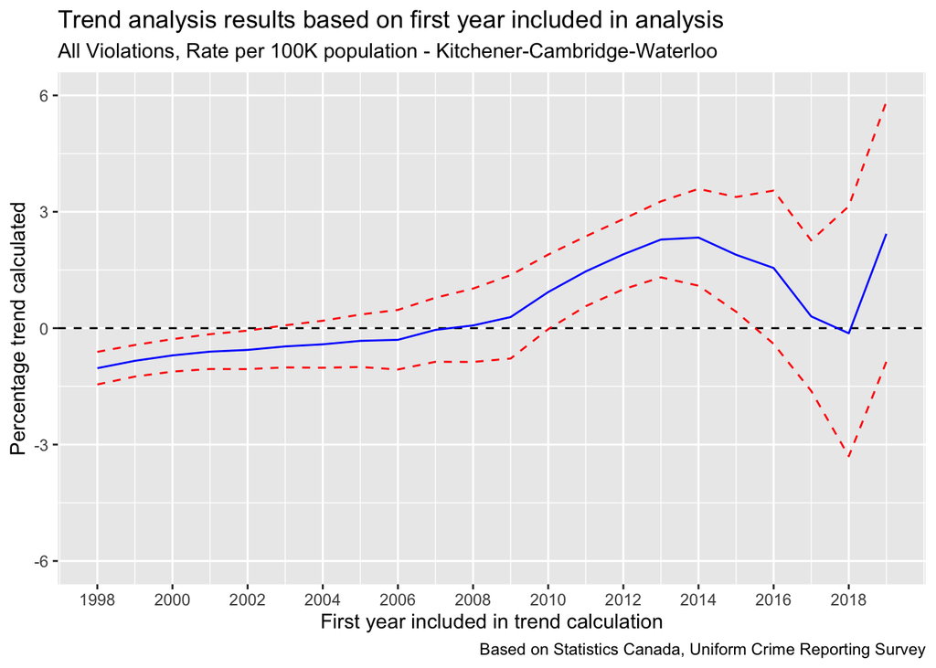

```r
ggplot(trend_result_data_lognormal, aes(x = years, y = middle)) +
  geom_hline(yintercept = 0, colour = "black", linetype = "dashed") +
  geom_line(colour = "blue") +
  geom_line(aes(y = upper_ci), colour = "red", linetype = "dashed") +
  geom_line(aes(y = lower_ci), colour = "red", linetype = "dashed") +
  coord_cartesian(ylim = c(-6, 6)) +
  scale_x_continuous(breaks = seq(1998, 2019, 2)) +
  labs(title = "Trend analysis results based on first year included in analysis",
       subtitle = "All Violations, Rate per 100K population - Kitchener-Cambridge-Waterloo",
       x = "First year included in trend calculation",
       y = "Percentage trend calculated",
       caption = "Based on Statistics Canada, Uniform Crime Reporting Survey")
```

Using a log-inverse-Gaussian distribution:

```r
trend_result_data_inverse_gaussian = trend_sensitivity_test(x = overall_incidents_data %>% pull(REF_DATE),
                                                            y = overall_incidents_data %>% pull(VALUE),
                                                            method = "log-inverse-gaussian") %>%
  rename(years = x_range)
```

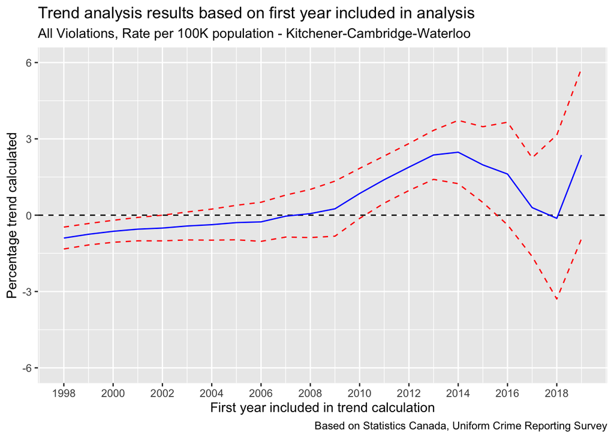

```r
ggplot(trend_result_data_inverse_gaussian, aes(x = years, y = middle)) +
  geom_hline(yintercept = 0, colour = "black", linetype = "dashed") +
  geom_line(colour = "blue") +
  geom_line(aes(y = upper_ci), colour = "red", linetype = "dashed") +
  geom_line(aes(y = lower_ci), colour = "red", linetype = "dashed") +
  coord_cartesian(ylim = c(-6, 6)) +
  scale_x_continuous(breaks = seq(1998, 2019, 2)) +
  labs(title = "Trend analysis results based on first year included in analysis",
       subtitle = "All Violations, Rate per 100K population - Kitchener-Cambridge-Waterloo",
       x = "First year included in trend calculation",
       y = "Percentage trend calculated",
       caption = "Based on Statistics Canada, Uniform Crime Reporting Survey")
```

Using a linear model:

```r
trend_result_data_linear = trend_sensitivity_test(x = overall_incidents_data %>% pull(REF_DATE),
                                           y = overall_incidents_data %>% pull(VALUE),
                                           method = "linear") %>%
  rename(years = x_range)
```

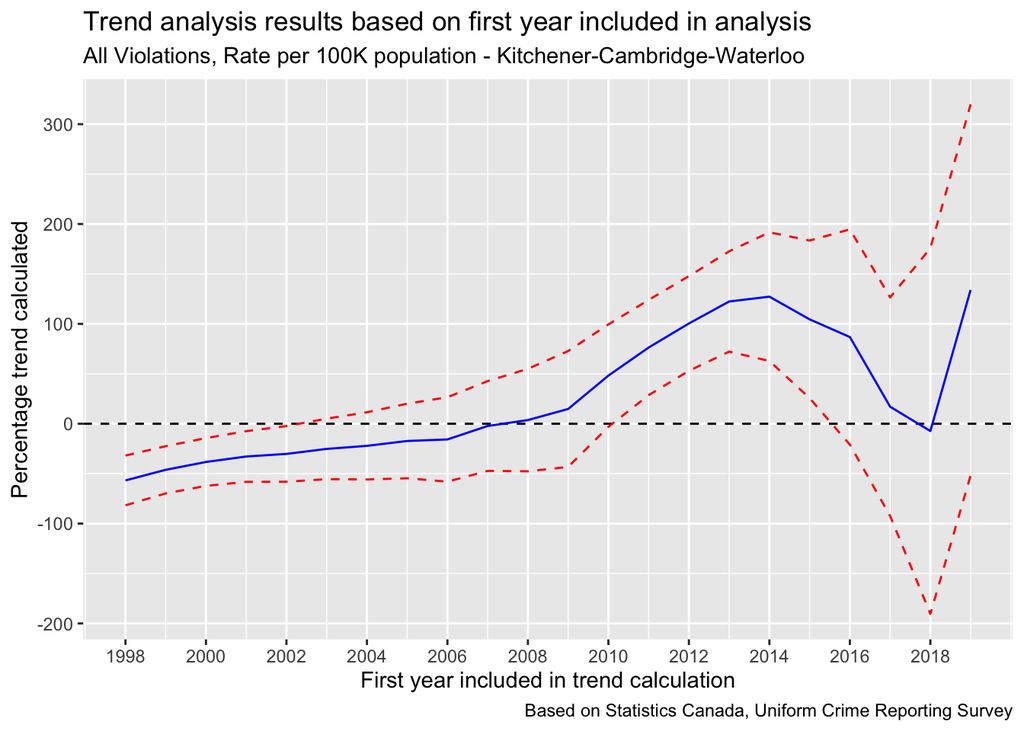

```r
ggplot(trend_result_data_linear, aes(x = years, y = middle)) +
  geom_hline(yintercept = 0, colour = "black", linetype = "dashed") +
  geom_line(colour = "blue") +
  geom_line(aes(y = upper_ci), colour = "red", linetype = "dashed") +
  geom_line(aes(y = lower_ci), colour = "red", linetype = "dashed") +
  scale_x_continuous(breaks = seq(1998, 2019, 2)) +
  labs(title = "Trend analysis results based on first year included in analysis",
       subtitle = "All Violations, Rate per 100K population - Kitchener-Cambridge-Waterloo",
       x = "First year included in trend calculation",
       y = "Percentage trend calculated",
       caption = "Based on Statistics Canada, Uniform Crime Reporting Survey")
```

# What does a consistent trend look like?

This section contains a contrasting example where there is a consistent trend, and in which the results are similar regardless of the starting point selected for the trend analysis:

```r
theft_under_5000_data = reported_crime_data %>%
  filter(Violations == "Theft $5,000 or under [2140]" & Statistics == "Rate per 100,000 population")
```

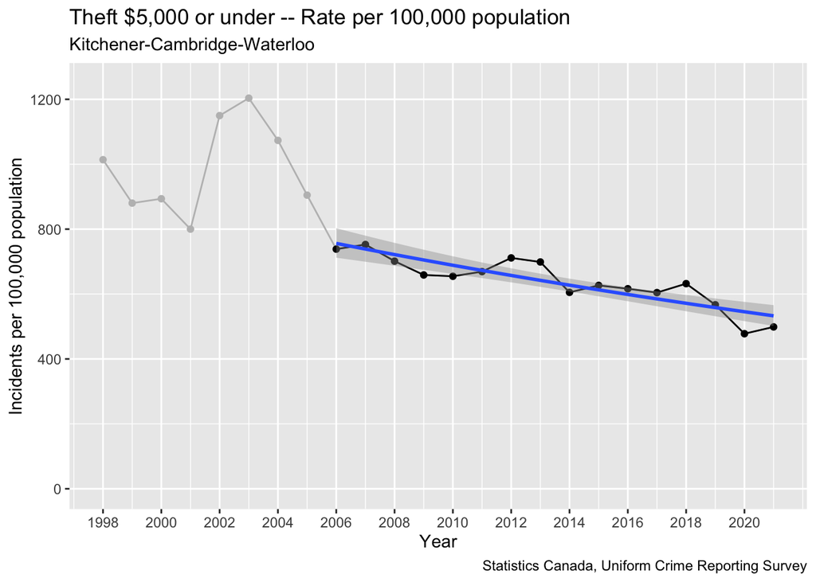

```r
ggplot(data = theft_under_5000_data, aes(x = REF_DATE, y = VALUE)) +
  geom_line(colour = "grey") +
  geom_point(colour = "grey") +
  geom_line(data = theft_under_5000_data %>% filter(REF_DATE >= 2006)) +
  geom_point(data = theft_under_5000_data %>% filter(REF_DATE >= 2006)) +
  geom_smooth(data = theft_under_5000_data %>% filter(REF_DATE >= 2006), method = "glm", method.args = list(family = Gamma(link = "log"))) +
  scale_x_continuous(breaks = seq(1998, 2021, 2)) +
  coord_cartesian(ylim = c(0, 1250)) +
  labs(title = "Theft $5,000 or under -- Rate per 100,000 population",
       subtitle = "Kitchener-Cambridge-Waterloo",
       x = "Year",
       y = "Incidents per 100,000 population",
       caption = "Statistics Canada, Uniform Crime Reporting Survey")
```

```r
ggsave("./theft_under_5000_2006-2021.jpg", device = "jpeg")
```

Perform a sensitivity test on the starting point assumption:

```r
trend_result_data_theft = trend_sensitivity_test(x = theft_under_5000_data %>% pull(REF_DATE),
                                           y = theft_under_5000_data %>% pull(VALUE),
                                           method = "log-gamma") %>%
  rename(years = x_range)
```

```r
trend_result_data_theft
```

```
##    years  upper_ci    middle   lower_ci
## 1   1998 -2.348892 -3.086508  -3.818553
## 2   1999 -2.336483 -3.135212  -3.927408
## 3   2000 -2.492025 -3.318889  -4.138742
## 4   2001 -2.628920 -3.494027  -4.351447
## 5   2002 -2.963327 -3.801018  -4.631478
## 6   2003 -2.693342 -3.600564  -4.499327
## 7   2004 -2.293829 -3.123158  -3.945448
## 8   2005 -1.927822 -2.626980  -3.321153
## 9   2006 -1.622611 -2.305085  -2.982824
## 10  2007 -1.596796 -2.372056  -3.141208
## 11  2008 -1.435447 -2.330182  -3.216796
## 12  2009 -1.415542 -2.447358  -3.468374
## 13  2010 -1.670160 -2.792959  -3.902936
## 14  2011 -2.040888 -3.236688  -4.417891
## 15  2012 -2.319330 -3.653811  -4.970060
## 16  2013 -1.961561 -3.637648  -5.285081
## 17  2014 -1.244793 -3.394145  -5.496718
## 18  2015 -1.952993 -4.376171  -6.739462
## 19  2016 -2.090449 -5.204836  -8.220159
## 20  2017 -2.289517 -6.430664 -10.396301
## 21  2018 -2.654415 -8.387760 -13.783429
## 22  2019  5.883888 -6.211880 -16.925874
```

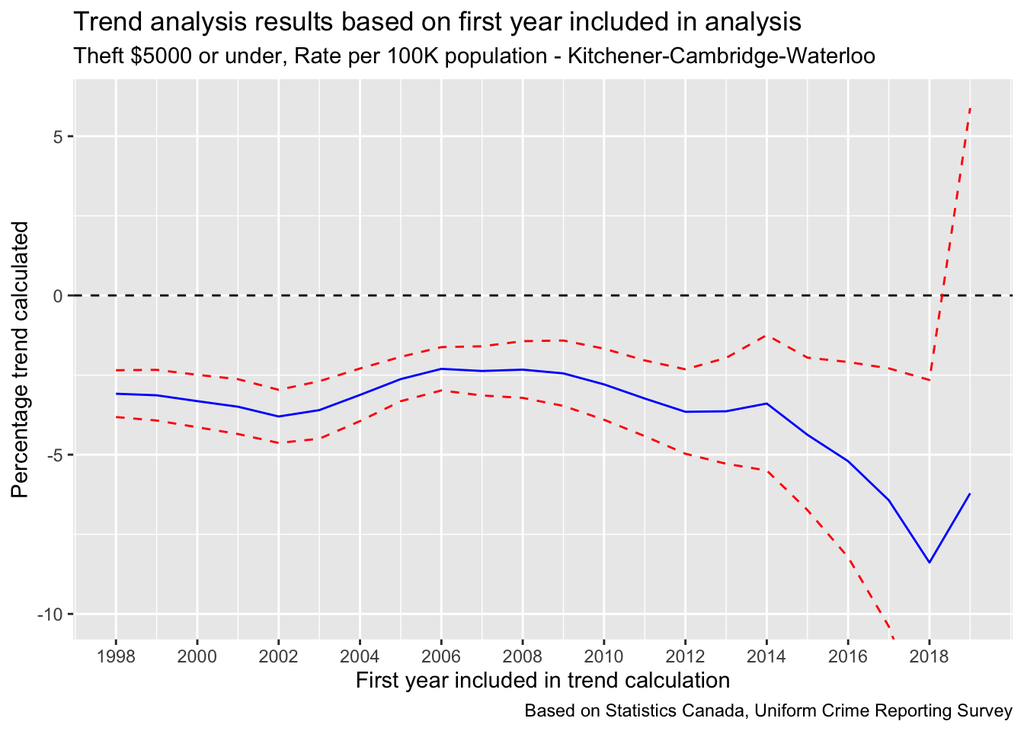

```r
ggplot(trend_result_data_theft, aes(x = years, y = middle)) +
  geom_hline(yintercept = 0, colour = "black", linetype = "dashed") +
  geom_line(colour = "blue") +
  geom_line(aes(y = upper_ci), colour = "red", linetype = "dashed") +
  geom_line(aes(y = lower_ci), colour = "red", linetype = "dashed") +
  coord_cartesian(ylim = c(-10, 6)) +
  scale_x_continuous(breaks = seq(1998, 2018, 2)) +
  labs(title = "Trend analysis results based on first year included in analysis",
       subtitle = "Theft $5000 or under, Rate per 100K population - Kitchener-Cambridge-Waterloo",
       x = "First year included in trend calculation",
       y = "Percentage trend calculated",
       caption = "Based on Statistics Canada, Uniform Crime Reporting Survey")
```

```r
ggsave("./theft_sensitivity_analysis.jpg", device = "jpeg")
```